# Risk Factor Analysis

## Outcome Variable

**Outcome Variable:** haz

## Predictor Variables

**Intervention Variable:** mwtkg

**Adjustment Set:**

- arm
- W_mage
- W_fage
- meducyrs
- feducyrs
- single
- brthmon
- W_gagebrth
- W_birthwt
- W_birthlen
- vagbrth
- delta_W_mage
- delta_W_fage
- delta_meducyrs
- delta_feducyrs
- delta_single
- delta_brthmon
- delta_W_gagebrth
- delta_W_birthwt
- delta_W_birthlen
- delta_vagbrth

## Stratifying Variables

The analysis was stratified on these variable(s):

- agecat
- studyid
- country

## Data Summary

| agecat | studyid | country | mwtkg | n_cell | n |
| --- | --- | --- | --- | --- | --- |
| 6 months | ki0047075b-MAL-ED | BANGLADESH | >=58 kg | 46 | 241 |
| 6 months | ki0047075b-MAL-ED | BANGLADESH | <52 kg | 154 | 241 |
| 6 months | ki0047075b-MAL-ED | BANGLADESH | [52-58) kg | 41 | 241 |
| 6 months | ki0047075b-MAL-ED | BRAZIL | >=58 kg | 137 | 208 |
| 6 months | ki0047075b-MAL-ED | BRAZIL | <52 kg | 37 | 208 |
| 6 months | ki0047075b-MAL-ED | BRAZIL | [52-58) kg | 34 | 208 |
| 6 months | ki0047075b-MAL-ED | INDIA | >=58 kg | 40 | 235 |
| 6 months | ki0047075b-MAL-ED | INDIA | <52 kg | 146 | 235 |
| 6 months | ki0047075b-MAL-ED | INDIA | [52-58) kg | 49 | 235 |
| 6 months | ki0047075b-MAL-ED | NEPAL | >=58 kg | 79 | 236 |
| 6 months | ki0047075b-MAL-ED | NEPAL | <52 kg | 75 | 236 |
| 6 months | ki0047075b-MAL-ED | NEPAL | [52-58) kg | 82 | 236 |
| 6 months | ki0047075b-MAL-ED | PERU | >=58 kg | 100 | 272 |
| 6 months | ki0047075b-MAL-ED | PERU | <52 kg | 107 | 272 |
| 6 months | ki0047075b-MAL-ED | PERU | [52-58) kg | 65 | 272 |
| 6 months | ki0047075b-MAL-ED | SOUTH AFRICA | >=58 kg | 179 | 249 |
| 6 months | ki0047075b-MAL-ED | SOUTH AFRICA | <52 kg | 29 | 249 |
| 6 months | ki0047075b-MAL-ED | SOUTH AFRICA | [52-58) kg | 41 | 249 |
| 6 months | ki0047075b-MAL-ED | TANZANIA, UNITED REPUBLIC OF | >=58 kg | 94 | 247 |
| 6 months | ki0047075b-MAL-ED | TANZANIA, UNITED REPUBLIC OF | <52 kg | 95 | 247 |
| 6 months | ki0047075b-MAL-ED | TANZANIA, UNITED REPUBLIC OF | [52-58) kg | 58 | 247 |
| 6 months | ki1000304b-SAS-CompFeed | INDIA | >=58 kg | 99 | 1330 |
| 6 months | ki1000304b-SAS-CompFeed | INDIA | <52 kg | 1019 | 1330 |
| 6 months | ki1000304b-SAS-CompFeed | INDIA | [52-58) kg | 212 | 1330 |
| 6 months | ki1017093-NIH-Birth | BANGLADESH | >=58 kg | 71 | 537 |
| 6 months | ki1017093-NIH-Birth | BANGLADESH | <52 kg | 385 | 537 |
| 6 months | ki1017093-NIH-Birth | BANGLADESH | [52-58) kg | 81 | 537 |
| 6 months | ki1017093b-PROVIDE | BANGLADESH | >=58 kg | 107 | 582 |
| 6 months | ki1017093b-PROVIDE | BANGLADESH | <52 kg | 369 | 582 |
| 6 months | ki1017093b-PROVIDE | BANGLADESH | [52-58) kg | 106 | 582 |

[output cut: 57 more lines]

The following strata were considered:

- agecat: 24 months, studyid: ki0047075b-MAL-ED, country: BANGLADESH
- agecat: 24 months, studyid: ki0047075b-MAL-ED, country: BRAZIL
- agecat: 24 months, studyid: ki0047075b-MAL-ED, country: INDIA
- agecat: 24 months, studyid: ki0047075b-MAL-ED, country: NEPAL
- agecat: 24 months, studyid: ki0047075b-MAL-ED, country: PERU
- agecat: 24 months, studyid: ki0047075b-MAL-ED, country: SOUTH AFRICA
- agecat: 24 months, studyid: ki0047075b-MAL-ED, country: TANZANIA, UNITED REPUBLIC OF
- agecat: 24 months, studyid: ki1017093-NIH-Birth, country: BANGLADESH
- agecat: 24 months, studyid: ki1017093b-PROVIDE, country: BANGLADESH
- agecat: 24 months, studyid: ki1017093c-NIH-Crypto, country: BANGLADESH
- agecat: 24 months, studyid: ki1066203-TanzaniaChild2, country: TANZANIA, UNITED REPUBLIC OF
- agecat: 24 months, studyid: ki1119695-PROBIT, country: BELARUS
- agecat: 24 months, studyid: ki1126311-ZVITAMBO, country: ZIMBABWE
- agecat: 24 months, studyid: ki1148112-LCNI-5, country: MALAWI
- agecat: 6 months, studyid: ki0047075b-MAL-ED, country: BANGLADESH
- agecat: 6 months, studyid: ki0047075b-MAL-ED, country: BRAZIL
- agecat: 6 months, studyid: ki0047075b-MAL-ED, country: INDIA
- agecat: 6 months, studyid: ki0047075b-MAL-ED, country: NEPAL
- agecat: 6 months, studyid: ki0047075b-MAL-ED, country: PERU
- agecat: 6 months, studyid: ki0047075b-MAL-ED, country: SOUTH AFRICA
- agecat: 6 months, studyid: ki0047075b-MAL-ED, country: TANZANIA, UNITED REPUBLIC OF
- agecat: 6 months, studyid: ki1000304b-SAS-CompFeed, country: INDIA
- agecat: 6 months, studyid: ki1017093-NIH-Birth, country: BANGLADESH
- agecat: 6 months, studyid: ki1017093b-PROVIDE, country: BANGLADESH
- agecat: 6 months, studyid: ki1017093c-NIH-Crypto, country: BANGLADESH
- agecat: 6 months, studyid: ki1066203-TanzaniaChild2, country: TANZANIA, UNITED REPUBLIC OF
- agecat: 6 months, studyid: ki1119695-PROBIT, country: BELARUS
- agecat: 6 months, studyid: ki1126311-ZVITAMBO, country: ZIMBABWE
- agecat: 6 months, studyid: ki1148112-LCNI-5, country: MALAWI

### Dropped Strata

Some strata were dropped due to rare outcomes:

- agecat: 24 months, studyid: ki1066203-TanzaniaChild2, country: TANZANIA, UNITED REPUBLIC OF

## Methods Detail

We’re interested in the causal parameters $E[Y_a]$ for all values of $a \in \mathcal{A}$. These parameters represent the mean outcome if, possibly contrary to fact, we intervened to set all units to have $A=a$. Under the randomization and positivity assumptions, these are identified by the statistical parameters $\psi_a=E_W[E_{Y|A,W}(Y|A=a,W)]$. In addition, we’re interested in the mean of $Y$, $E[Y]$ under no intervention (the observed mean). We will estimate these parameters by using SuperLearner to fit the relevant likelihood factors – $E_{Y|A,W}(Y|A=a,W)$ and $p(A=a|W)$, and then updating our likelihood fit using a joint TMLE.

For unadjusted analyses ($W=\{\}$), initial likelihoods were estimated using Lrnr_glm to estimate the simple $E(Y|A)$ and Lrnr_mean to estimate $p(A)$. For adjusted analyses, a small library containing Lrnr_glmnet, Lrnr_xgboost, and Lrnr_mean was used.

Having estimated these parameters, we will then use the delta method to estimate relative risks and attributable risks relative to a prespecified baseline level of $A$.

# Results Detail

## Results Plots

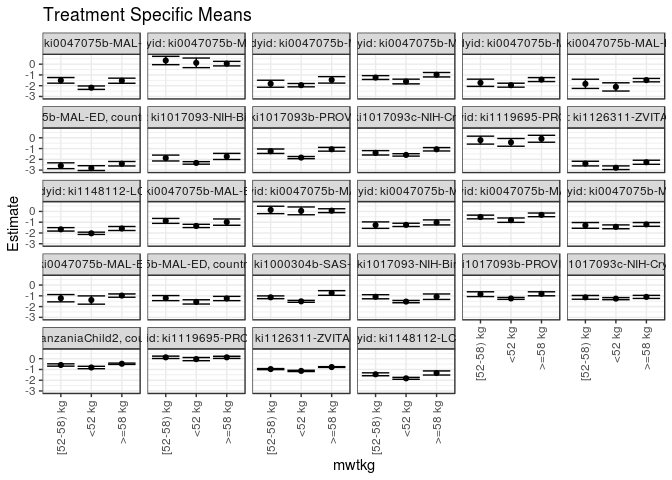

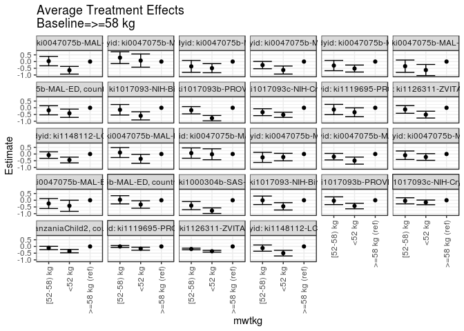

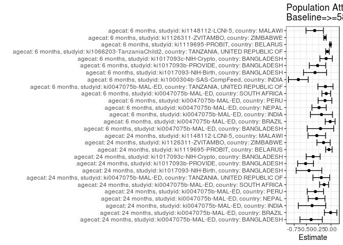

## Results Table

### Parameter: TSM

| agecat | studyid | country | intervention_level | baseline_level | estimate | ci_lower | ci_upper |
| --- | --- | --- | --- | --- | --- | --- | --- |
| 6 months | ki0047075b-MAL-ED | BANGLADESH | >=58 kg | NA | -0.9914174 | -1.2845919 | -0.6982429 |
| 6 months | ki0047075b-MAL-ED | BANGLADESH | <52 kg | NA | -1.3486839 | -1.5005342 | -1.1968336 |
| 6 months | ki0047075b-MAL-ED | BANGLADESH | [52-58) kg | NA | -0.8817087 | -1.1107908 | -0.6526266 |
| 6 months | ki0047075b-MAL-ED | BRAZIL | >=58 kg | NA | 0.0697459 | -0.1089842 | 0.2484760 |
| 6 months | ki0047075b-MAL-ED | BRAZIL | <52 kg | NA | 0.0516075 | -0.3105731 | 0.4137882 |
| 6 months | ki0047075b-MAL-ED | BRAZIL | [52-58) kg | NA | 0.1387540 | -0.2053664 | 0.4828743 |
| 6 months | ki0047075b-MAL-ED | INDIA | >=58 kg | NA | -1.0214898 | -1.2546397 | -0.7883398 |
| 6 months | ki0047075b-MAL-ED | INDIA | <52 kg | NA | -1.2497702 | -1.4011741 | -1.0983664 |
| 6 months | ki0047075b-MAL-ED | INDIA | [52-58) kg | NA | -1.2722430 | -1.5721407 | -0.9723453 |
| 6 months | ki0047075b-MAL-ED | NEPAL | >=58 kg | NA | -0.3184160 | -0.4896459 | -0.1471861 |
| 6 months | ki0047075b-MAL-ED | NEPAL | <52 kg | NA | -0.8114600 | -1.0157898 | -0.6071303 |
| 6 months | ki0047075b-MAL-ED | NEPAL | [52-58) kg | NA | -0.5165920 | -0.6893038 | -0.3438802 |
| 6 months | ki0047075b-MAL-ED | PERU | >=58 kg | NA | -1.2058460 | -1.3795101 | -1.0321820 |
| 6 months | ki0047075b-MAL-ED | PERU | <52 kg | NA | -1.4295705 | -1.6064647 | -1.2526762 |
| 6 months | ki0047075b-MAL-ED | PERU | [52-58) kg | NA | -1.2973253 | -1.5637728 | -1.0308778 |
| 6 months | ki0047075b-MAL-ED | SOUTH AFRICA | >=58 kg | NA | -0.9764674 | -1.1291542 | -0.8237805 |
| 6 months | ki0047075b-MAL-ED | SOUTH AFRICA | <52 kg | NA | -1.3911647 | -1.7755905 | -1.0067390 |
| 6 months | ki0047075b-MAL-ED | SOUTH AFRICA | [52-58) kg | NA | -1.2213752 | -1.5596816 | -0.8830688 |
| 6 months | ki0047075b-MAL-ED | TANZANIA, UNITED REPUBLIC OF | >=58 kg | NA | -1.2467738 | -1.4446811 | -1.0488664 |
| 6 months | ki0047075b-MAL-ED | TANZANIA, UNITED REPUBLIC OF | <52 kg | NA | -1.5648308 | -1.7612005 | -1.3684610 |
| 6 months | ki0047075b-MAL-ED | TANZANIA, UNITED REPUBLIC OF | [52-58) kg | NA | -1.2124425 | -1.4484467 | -0.9764383 |
| 6 months | ki1000304b-SAS-CompFeed | INDIA | >=58 kg | NA | -0.7356543 | -0.9502115 | -0.5210971 |
| 6 months | ki1000304b-SAS-CompFeed | INDIA | <52 kg | NA | -1.5143701 | -1.6033615 | -1.4253787 |
| 6 months | ki1000304b-SAS-CompFeed | INDIA | [52-58) kg | NA | -1.1361960 | -1.2641623 | -1.0082297 |
| 6 months | ki1017093-NIH-Birth | BANGLADESH | >=58 kg | NA | -1.0819734 | -1.3355404 | -0.8284065 |
| 6 months | ki1017093-NIH-Birth | BANGLADESH | <52 kg | NA | -1.5358463 | -1.6406098 | -1.4310828 |
| 6 months | ki1017093-NIH-Birth | BANGLADESH | [52-58) kg | NA | -1.0866922 | -1.2768304 | -0.8965539 |
| 6 months | ki1017093b-PROVIDE | BANGLADESH | >=58 kg | NA | -0.8114955 | -0.9975152 | -0.6254757 |
| 6 months | ki1017093b-PROVIDE | BANGLADESH | <52 kg | NA | -1.2420629 | -1.3306850 | -1.1534408 |
| 6 months | ki1017093b-PROVIDE | BANGLADESH | [52-58) kg | NA | -0.8477725 | -1.0686029 | -0.6269420 |

[output cut: 54 more lines]

### Parameter: E(Y)

| agecat | studyid | country | intervention_level | baseline_level | estimate | ci_lower | ci_upper |
| --- | --- | --- | --- | --- | --- | --- | --- |
| 6 months | ki0047075b-MAL-ED | BANGLADESH | NA | NA | -1.2056777 | -1.3231497 | -1.0882058 |
| 6 months | ki0047075b-MAL-ED | BRAZIL | NA | NA | 0.0532131 | -0.0914567 | 0.1978830 |
| 6 months | ki0047075b-MAL-ED | INDIA | NA | NA | -1.2148369 | -1.3332371 | -1.0964367 |
| 6 months | ki0047075b-MAL-ED | NEPAL | NA | NA | -0.5610593 | -0.6737915 | -0.4483272 |
| 6 months | ki0047075b-MAL-ED | PERU | NA | NA | -1.3272488 | -1.4359649 | -1.2185326 |
| 6 months | ki0047075b-MAL-ED | SOUTH AFRICA | NA | NA | -1.0728012 | -1.2026830 | -0.9429194 |
| 6 months | ki0047075b-MAL-ED | TANZANIA, UNITED REPUBLIC OF | NA | NA | -1.3601215 | -1.4821830 | -1.2380600 |
| 6 months | ki1000304b-SAS-CompFeed | INDIA | NA | NA | -1.4006917 | -1.4821813 | -1.3192022 |
| 6 months | ki1017093-NIH-Birth | BANGLADESH | NA | NA | -1.4073821 | -1.4960598 | -1.3187043 |
| 6 months | ki1017093b-PROVIDE | BANGLADESH | NA | NA | -1.0848568 | -1.1613109 | -1.0084028 |
| 6 months | ki1017093c-NIH-Crypto | BANGLADESH | NA | NA | -1.1986783 | -1.2700937 | -1.1272630 |
| 6 months | ki1066203-TanzaniaChild2 | TANZANIA, UNITED REPUBLIC OF | NA | NA | -0.5424765 | -0.5918460 | -0.4931071 |
| 6 months | ki1119695-PROBIT | BELARUS | NA | NA | 0.1143882 | 0.0212298 | 0.2075466 |
| 6 months | ki1126311-ZVITAMBO | ZIMBABWE | NA | NA | -0.8994195 | -0.9257684 | -0.8730707 |
| 6 months | ki1148112-LCNI-5 | MALAWI | NA | NA | -1.6584707 | -1.7281551 | -1.5887863 |
| 24 months | ki0047075b-MAL-ED | BANGLADESH | NA | NA | -1.9431132 | -2.0691678 | -1.8170586 |
| 24 months | ki0047075b-MAL-ED | BRAZIL | NA | NA | 0.0418452 | -0.1263708 | 0.2100613 |
| 24 months | ki0047075b-MAL-ED | INDIA | NA | NA | -1.8439159 | -1.9704751 | -1.7173568 |
| 24 months | ki0047075b-MAL-ED | NEPAL | NA | NA | -1.2752193 | -1.3954783 | -1.1549603 |
| 24 months | ki0047075b-MAL-ED | PERU | NA | NA | -1.7500995 | -1.8705474 | -1.6296516 |
| 24 months | ki0047075b-MAL-ED | SOUTH AFRICA | NA | NA | -1.6220299 | -1.7590593 | -1.4850005 |
| 24 months | ki0047075b-MAL-ED | TANZANIA, UNITED REPUBLIC OF | NA | NA | -2.6058879 | -2.7403043 | -2.4714714 |
| 24 months | ki1017093-NIH-Birth | BANGLADESH | NA | NA | -2.1807945 | -2.2835902 | -2.0779987 |
| 24 months | ki1017093b-PROVIDE | BANGLADESH | NA | NA | -1.5839236 | -1.6672059 | -1.5006413 |
| 24 months | ki1017093c-NIH-Crypto | BANGLADESH | NA | NA | -1.4295331 | -1.5127726 | -1.3462935 |
| 24 months | ki1119695-PROBIT | BELARUS | NA | NA | -0.1312742 | -0.4286264 | 0.1660780 |
| 24 months | ki1126311-ZVITAMBO | ZIMBABWE | NA | NA | -2.4241972 | -2.5387692 | -2.3096253 |
| 24 months | ki1148112-LCNI-5 | MALAWI | NA | NA | -1.8747405 | -1.9558403 | -1.7936407 |

### Parameter: ATE

| agecat | studyid | country | intervention_level | baseline_level | estimate | ci_lower | ci_upper |
| --- | --- | --- | --- | --- | --- | --- | --- |
| 6 months | ki0047075b-MAL-ED | BANGLADESH | >=58 kg | >=58 kg | 0.0000000 | 0.0000000 | 0.0000000 |
| 6 months | ki0047075b-MAL-ED | BANGLADESH | <52 kg | >=58 kg | -0.3572665 | -0.6884872 | -0.0260458 |
| 6 months | ki0047075b-MAL-ED | BANGLADESH | [52-58) kg | >=58 kg | 0.1097087 | -0.2626094 | 0.4820268 |
| 6 months | ki0047075b-MAL-ED | BRAZIL | >=58 kg | >=58 kg | 0.0000000 | 0.0000000 | 0.0000000 |
| 6 months | ki0047075b-MAL-ED | BRAZIL | <52 kg | >=58 kg | -0.0181384 | -0.4250073 | 0.3887306 |
| 6 months | ki0047075b-MAL-ED | BRAZIL | [52-58) kg | >=58 kg | 0.0690081 | -0.3164170 | 0.4544331 |
| 6 months | ki0047075b-MAL-ED | INDIA | >=58 kg | >=58 kg | 0.0000000 | 0.0000000 | 0.0000000 |
| 6 months | ki0047075b-MAL-ED | INDIA | <52 kg | >=58 kg | -0.2282805 | -0.5046992 | 0.0481382 |
| 6 months | ki0047075b-MAL-ED | INDIA | [52-58) kg | >=58 kg | -0.2507533 | -0.6284838 | 0.1269773 |
| 6 months | ki0047075b-MAL-ED | NEPAL | >=58 kg | >=58 kg | 0.0000000 | 0.0000000 | 0.0000000 |
| 6 months | ki0047075b-MAL-ED | NEPAL | <52 kg | >=58 kg | -0.4930440 | -0.7544653 | -0.2316228 |
| 6 months | ki0047075b-MAL-ED | NEPAL | [52-58) kg | >=58 kg | -0.1981760 | -0.4397694 | 0.0434174 |
| 6 months | ki0047075b-MAL-ED | PERU | >=58 kg | >=58 kg | 0.0000000 | 0.0000000 | 0.0000000 |
| 6 months | ki0047075b-MAL-ED | PERU | <52 kg | >=58 kg | -0.2237244 | -0.4726450 | 0.0251962 |
| 6 months | ki0047075b-MAL-ED | PERU | [52-58) kg | >=58 kg | -0.0914792 | -0.4094624 | 0.2265040 |
| 6 months | ki0047075b-MAL-ED | SOUTH AFRICA | >=58 kg | >=58 kg | 0.0000000 | 0.0000000 | 0.0000000 |
| 6 months | ki0047075b-MAL-ED | SOUTH AFRICA | <52 kg | >=58 kg | -0.4146974 | -0.8280052 | -0.0013895 |
| 6 months | ki0047075b-MAL-ED | SOUTH AFRICA | [52-58) kg | >=58 kg | -0.2449078 | -0.6171996 | 0.1273839 |
| 6 months | ki0047075b-MAL-ED | TANZANIA, UNITED REPUBLIC OF | >=58 kg | >=58 kg | 0.0000000 | 0.0000000 | 0.0000000 |
| 6 months | ki0047075b-MAL-ED | TANZANIA, UNITED REPUBLIC OF | <52 kg | >=58 kg | -0.3180570 | -0.5951421 | -0.0409719 |
| 6 months | ki0047075b-MAL-ED | TANZANIA, UNITED REPUBLIC OF | [52-58) kg | >=58 kg | 0.0343313 | -0.2717352 | 0.3403978 |
| 6 months | ki1000304b-SAS-CompFeed | INDIA | >=58 kg | >=58 kg | 0.0000000 | 0.0000000 | 0.0000000 |
| 6 months | ki1000304b-SAS-CompFeed | INDIA | <52 kg | >=58 kg | -0.7787158 | -0.9867975 | -0.5706342 |
| 6 months | ki1000304b-SAS-CompFeed | INDIA | [52-58) kg | >=58 kg | -0.4005417 | -0.7031260 | -0.0979574 |
| 6 months | ki1017093-NIH-Birth | BANGLADESH | >=58 kg | >=58 kg | 0.0000000 | 0.0000000 | 0.0000000 |
| 6 months | ki1017093-NIH-Birth | BANGLADESH | <52 kg | >=58 kg | -0.4538728 | -0.7276983 | -0.1800474 |
| 6 months | ki1017093-NIH-Birth | BANGLADESH | [52-58) kg | >=58 kg | -0.0047187 | -0.3213781 | 0.3119407 |
| 6 months | ki1017093b-PROVIDE | BANGLADESH | >=58 kg | >=58 kg | 0.0000000 | 0.0000000 | 0.0000000 |
| 6 months | ki1017093b-PROVIDE | BANGLADESH | <52 kg | >=58 kg | -0.4305675 | -0.6363976 | -0.2247373 |
| 6 months | ki1017093b-PROVIDE | BANGLADESH | [52-58) kg | >=58 kg | -0.0362770 | -0.3246754 | 0.2521214 |

[output cut: 54 more lines]

### Parameter: PAR

| agecat | studyid | country | intervention_level | baseline_level | estimate | ci_lower | ci_upper |
| --- | --- | --- | --- | --- | --- | --- | --- |
| 6 months | ki0047075b-MAL-ED | BANGLADESH | >=58 kg | NA | -0.2142603 | -0.4834233 | 0.0549027 |
| 6 months | ki0047075b-MAL-ED | BRAZIL | >=58 kg | NA | -0.0165328 | -0.1169520 | 0.0838865 |
| 6 months | ki0047075b-MAL-ED | INDIA | >=58 kg | NA | -0.1933471 | -0.4178837 | 0.0311895 |
| 6 months | ki0047075b-MAL-ED | NEPAL | >=58 kg | NA | -0.2426433 | -0.3885273 | -0.0967594 |
| 6 months | ki0047075b-MAL-ED | PERU | >=58 kg | NA | -0.1214027 | -0.2617045 | 0.0188991 |
| 6 months | ki0047075b-MAL-ED | SOUTH AFRICA | >=58 kg | NA | -0.0963339 | -0.1849396 | -0.0077281 |
| 6 months | ki0047075b-MAL-ED | TANZANIA, UNITED REPUBLIC OF | >=58 kg | NA | -0.1133477 | -0.2678224 | 0.0411270 |
| 6 months | ki1000304b-SAS-CompFeed | INDIA | >=58 kg | NA | -0.6650374 | -0.8651862 | -0.4648887 |
| 6 months | ki1017093-NIH-Birth | BANGLADESH | >=58 kg | NA | -0.3254086 | -0.5600434 | -0.0907738 |
| 6 months | ki1017093b-PROVIDE | BANGLADESH | >=58 kg | NA | -0.2733613 | -0.4413984 | -0.1053243 |
| 6 months | ki1017093c-NIH-Crypto | BANGLADESH | >=58 kg | NA | -0.0988634 | -0.2261026 | 0.0283759 |
| 6 months | ki1066203-TanzaniaChild2 | TANZANIA, UNITED REPUBLIC OF | >=58 kg | NA | -0.0718321 | -0.1082757 | -0.0353885 |
| 6 months | ki1119695-PROBIT | BELARUS | >=58 kg | NA | -0.0121640 | -0.0266410 | 0.0023129 |
| 6 months | ki1126311-ZVITAMBO | ZIMBABWE | >=58 kg | NA | -0.1220987 | -0.1465975 | -0.0975998 |
| 6 months | ki1148112-LCNI-5 | MALAWI | >=58 kg | NA | -0.3320184 | -0.5093567 | -0.1546801 |
| 24 months | ki0047075b-MAL-ED | BANGLADESH | >=58 kg | NA | -0.4049931 | -0.6330734 | -0.1769127 |
| 24 months | ki0047075b-MAL-ED | BRAZIL | >=58 kg | NA | -0.0073817 | -0.1342329 | 0.1194695 |
| 24 months | ki0047075b-MAL-ED | INDIA | >=58 kg | NA | -0.3855994 | -0.6650208 | -0.1061781 |
| 24 months | ki0047075b-MAL-ED | NEPAL | >=58 kg | NA | -0.2941737 | -0.4653476 | -0.1229998 |
| 24 months | ki0047075b-MAL-ED | PERU | >=58 kg | NA | -0.3178064 | -0.4831172 | -0.1524956 |
| 24 months | ki0047075b-MAL-ED | SOUTH AFRICA | >=58 kg | NA | -0.1396796 | -0.2307797 | -0.0485795 |
| 24 months | ki0047075b-MAL-ED | TANZANIA, UNITED REPUBLIC OF | >=58 kg | NA | -0.1972489 | -0.3678627 | -0.0266351 |
| 24 months | ki1017093-NIH-Birth | BANGLADESH | >=58 kg | NA | -0.4479635 | -0.7092110 | -0.1867161 |
| 24 months | ki1017093b-PROVIDE | BANGLADESH | >=58 kg | NA | -0.5172325 | -0.6783263 | -0.3561388 |
| 24 months | ki1017093c-NIH-Crypto | BANGLADESH | >=58 kg | NA | -0.3627516 | -0.5057400 | -0.2197633 |
| 24 months | ki1119695-PROBIT | BELARUS | >=58 kg | NA | -0.0423132 | -0.1078840 | 0.0232576 |
| 24 months | ki1126311-ZVITAMBO | ZIMBABWE | >=58 kg | NA | -0.1518063 | -0.2863465 | -0.0172661 |
| 24 months | ki1148112-LCNI-5 | MALAWI | >=58 kg | NA | -0.2888422 | -0.4680948 | -0.1095896 |